# Challenger

## Statistical Computing-1

### Name: Arnab Mukherjee Roll No: MB1908

In 1986, the space shuttle Challenger exploded during take off, killing the seven astronauts aboard. The explosion was the result of an O-ring failure, a splitting of a ring of rubber that seals the parts of the ship together. The accident was believed to be caused by the unusually cold weather (31 F or 0 C) at the time of the launch, as there is reason to believe that the O-ring failure probabilities increase as the temperature decreases. In this assignment first I will look into the dataset from frequentist approach and fit regular logistic regression and then I will fit different bayesian classification models and use MCMC to generate data from the posterior distribution

```python
#importing libraries
import numpy as np
import pandas as pd
import matplotlib.pyplot as plt
from sklearn.model_selection import train_test_split
from sklearn.metrics import confusion_matrix
from sklearn.metrics import accuracy_score
import seaborn as sns
import statsmodels.api as sm
from scipy import stats
import pymc3 as pm
from sklearn.metrics import classification_report
```

```python
cd "Documents"
```

```
C:\Users\Arnab\Documents
```

```python
df = pd.read_excel("data.xlsx")
```

```python
print("Challenger Dataset:")
df
```

```
Challenger Dataset:
```

|  | Failure | Temp |
| --- | --- | --- |
| 0 | 1 | 53 |
| 1 | 1 | 57 |
| 2 | 1 | 58 |
| 3 | 1 | 63 |
| 4 | 0 | 66 |
| 5 | 0 | 67 |
| 6 | 0 | 67 |
| 7 | 0 | 68 |
| 8 | 0 | 69 |
| 9 | 0 | 70 |
| 10 | 0 | 70 |
| 11 | 1 | 70 |
| 12 | 1 | 70 |
| 13 | 0 | 72 |
| 14 | 0 | 73 |
| 15 | 0 | 75 |
| 16 | 1 | 75 |
| 17 | 0 | 76 |
| 18 | 0 | 76 |
| 19 | 0 | 78 |
| 20 | 0 | 79 |
| 21 | 0 | 81 |

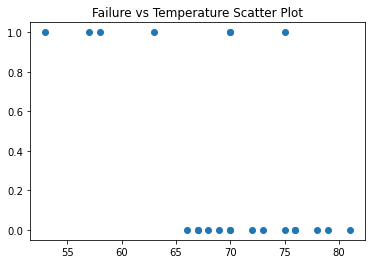

```python
plt.scatter(np.asarray(df["Temp"]),np.asarray(df["Failure"]))
plt.title("Failure vs Temperature Scatter Plot")
plt.show()
```

Now I will split the data into train and test dataset. Note that our dataset is already very small so we will keep ~50% data points for training and 50% data points for testing

```python
X = df["Temp"].values
y = df["Failure"].values
X_train, X_test, y_train, y_test = train_test_split(X, y, test_size=0.5, random_state=0)
```

Now I will fit regular logistic regression on this dataset

```python
lr = sm.Logit(y_train,sm.add_constant(X_train)).fit(disp = False)
```

```python
features = ["Temp"]
result = zip(['(Intercept)']+features,lr.params , lr.bse , lr.tvalues)
print('               Coefficient   Std. Error   Z Score')
print('-------------------------------------------------')
for term, coefficient, std_err, z_score in result:
    print(f'{term:>12}{coefficient:>14.3f}{std_err:>13.3f}{z_score:>10.3f}')
```

```
               Coefficient   Std. Error   Z Score
-------------------------------------------------
 (Intercept)        24.926       16.605     1.501
        Temp        -0.382        0.248    -1.538
```

```python
y_pred = lr.predict(sm.add_constant(X_test))
y_pred = list(map(round, y_pred))
cm = confusion_matrix(y_test, y_pred)
print(cm)
print('Accuracy ' + str(accuracy_score(y_test, y_pred)))
```

```
[[8 0]
 [2 1]]
Accuracy 0.8181818181818182
```

```python
print(classification_report(y_test,y_pred))
```

```
              precision    recall  f1-score   support

           0       0.80      1.00      0.89         8
           1       1.00      0.33      0.50         3

    accuracy                           0.82        11
   macro avg       0.90      0.67      0.69        11
weighted avg       0.85      0.82      0.78        11
```

One thing is already obvious from the confusion matrix that the regular logistic regression predicts non-failure points correctly but for failure points the accuracy drops to ~34%. This is a very serious problem because we want to predict the failure points with much higher precision. Now I will move to bayesian logistic regression. I will use PyMC3 package for this purpose.To build a Bayesian logistic regression model, we first have to put a prior distribution on each parameter. The choice of these priors will affect the outcome (though with more data, they probably will “converge” to the same distribution.)

Once our priors are specified, PyMC3 will numerically approximate the posterior distributions using Markov Chain Monte Carlo simulations and its generalizations. We can then use samples from these posteriors to make inferences.

### Model-1: Priors with Uniform Distribution

Since we have no prior knowledge about these parameters, we can assume that they could be anything. In other words, we assume that all β_var follows a uniform distribution with large lower and upper bounds. In order to catch a big net, we use big lower and upper bounds for our uniform distributions. I will use Metropolis Hastings method

```python
lower=-10**6
higher=10**6
with pm.Model() as first_model:
    #priors on parameters
    beta_0=pm.Uniform('beta_0', lower=lower, upper= higher)
    beta_temp=pm.Uniform('beta_temp', lower, higher)


    #the probability of belonging to class 1
    p = pm.Deterministic('p', pm.math.sigmoid(beta_0+beta_temp*df['Temp']))
with first_model:
    #fit the data
    observed=pm.Bernoulli("Failure", p, observed=df['Failure'])
    start=pm.find_MAP()
    step=pm.Metropolis()

    #samples from posterior distribution
    trace=pm.sample(25000, step=step, start=start)
    burned_trace=trace[15000:]
```

100.00% [34/34 00:00<00:00 logp = -38.681, ||grad|| = 3.5606e+05]

```
Multiprocess sampling (2 chains in 2 jobs)
CompoundStep
>Metropolis: [beta_temp]
>Metropolis: [beta_0]
```

100.00% [52000/52000 06:40<00:00 Sampling 2 chains, 0 divergences]

```
Sampling 2 chains for 1_000 tune and 25_000 draw iterations (2_000 + 50_000 draws total) took 411 seconds.
The rhat statistic is larger than 1.4 for some parameters. The sampler did not converge.
The estimated number of effective samples is smaller than 200 for some parameters.
```

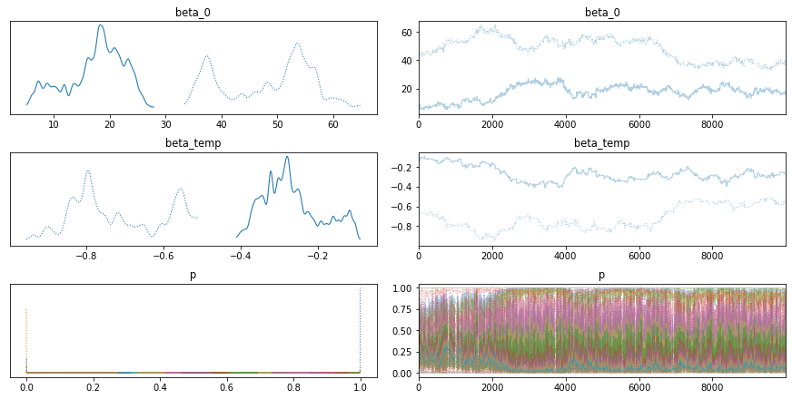

```python
pm.traceplot(burned_trace)
plt.show()
```

```python
coeffs=['beta_0', 'beta_temp']
d=dict()
for item in coeffs:
    d[item]=[burned_trace[item].mean()]

result_coeffs=pd.DataFrame.from_dict(d)
result_coeffs
```

|  | beta_0 | beta_temp |
| --- | --- | --- |
| 0 | 32.846668 | -0.491673 |

```python
#95% High Density Interval Computation
pm.stats.hpd(burned_trace['beta_0'])
coeffs=['beta_0', 'beta_temp']
interval=dict()
for item in coeffs:
    interval[item]=pm.stats.hpd(burned_trace[item]) #compute 95% high density interval

result_coeffs=pd.DataFrame.from_dict(interval).rename(index={0: 'lower', 1: 'upper'})
result_coeffs
```

|  | beta_0 | beta_temp |
| --- | --- | --- |
| lower | 7.081029 | -0.847359 |
| upper | 57.225042 | -0.114446 |

```python
coeffs=['beta_0', 'beta_temp', ]
d=dict()
for item in coeffs:
    d[item]=[float(start[item])]

map_coeffs=pd.DataFrame.from_dict(d)
map_coeffs
```

|  | beta_0 | beta_temp |
| --- | --- | --- |
| 0 | 15.533236 | -0.23756 |

```python
#Coefficient from regular logistic regression
lr = sm.Logit(y,sm.add_constant(X)).fit(disp = False)
features = ["Temp"]
result = zip(['(Intercept)']+features,lr.params , lr.bse , lr.tvalues)
print('               Coefficient   Std. Error   Z Score')
print('-------------------------------------------------')
for term, coefficient, std_err, z_score in result:
    print(f'{term:>12}{coefficient:>14.3f}{std_err:>13.3f}{z_score:>10.3f}')
```

```
               Coefficient   Std. Error   Z Score
-------------------------------------------------
 (Intercept)        15.533        7.596     2.045
        Temp        -0.238        0.111    -2.143
```

As we can see clearly our coefficients for classical logistic regression and bayesian logistic regression with uniform prior are almost identical. To make predictions with our Bayesian logistic model, we compute the 𝑦_score by averaging over our sample values.

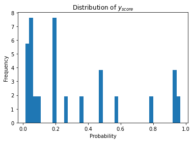

```python
#Prediction
#compute the average probability of predicting 1.
y_score = np.mean(burned_trace['p'], axis=0)#histogram of the distribution
plt.hist(y_score, bins=40, density=True)
plt.xlabel('Probability')
plt.ylabel('Frequency')
plt.title('Distribution of $y_{score}$')
plt.show()
```

```python
first_model_prediction=[1 if x >0.5 else 0 for x in y_score]
first_model_confussion_matrix =confusion_matrix(df['Failure'], first_model_prediction)
first_model_confussion_matrix
```

```
array([[14,  1],
       [ 3,  4]], dtype=int64)
```

```python
print(classification_report(y, first_model_prediction))
```

```
              precision    recall  f1-score   support

           0       0.82      0.93      0.87        15
           1       0.80      0.57      0.67         7

    accuracy                           0.82        22
   macro avg       0.81      0.75      0.77        22
weighted avg       0.82      0.82      0.81        22
```

### Model-2: Normal Prior

Now, let us train our model using a different set of priors. For example, we can assume that the coefficients follow normal distributions.

100.00% [27/27 00:00<00:00 logp = -30.012, ||grad|| = 49.474]

```
Multiprocess sampling (2 chains in 2 jobs)
CompoundStep
>Metropolis: [beta_temp]
>Metropolis: [beta_0]
```

100.00% [52000/52000 05:59<00:00 Sampling 2 chains, 0 divergences]

```
Sampling 2 chains for 1_000 tune and 25_000 draw iterations (2_000 + 50_000 draws total) took 369 seconds.
The estimated number of effective samples is smaller than 200 for some parameters.
```

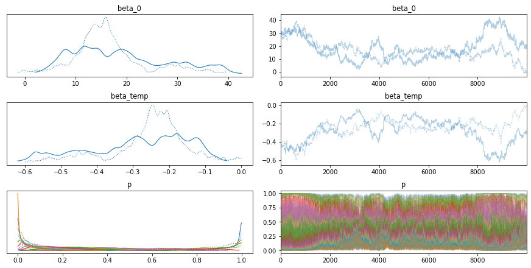

```python
with pm.Model() as second_model:
    #priors with normal distribution
    beta_0=pm.Normal('beta_0', mu=0, sd=10**4)
    beta_temp=pm.Normal('beta_temp', mu=0, sd=10**4)

    p = pm.Deterministic('p', pm.math.sigmoid(beta_0+beta_temp*df['Temp']))#fit observed data into the modelwith second_model:
    observed=pm.Bernoulli("Failure", p, observed=df['Failure'])
    start=pm.find_MAP()
    step=pm.Metropolis()
    second_trace=pm.sample(25000, step=step, start=start)
    second_burned_trace=second_trace[15000:]
pm.traceplot(second_burned_trace)
plt.show()
```

```python
coeffs=['beta_0', 'beta_temp']
d=dict()
for item in coeffs:
    d[item]=[float(start[item])]

second_map_coeffs=pd.DataFrame.from_dict(d)
second_map_coeffs
```

|  | beta_0 | beta_temp |
| --- | --- | --- |
| 0 | 15.53322 | -0.23756 |

They are very closed to the ones that we got in the first model. To go further, as we are in a Bayesian framework, we can even compare the posterior distributions across the two models. For example, let take a look at the intercept variable.

```
No handles with labels found to put in legend.
```

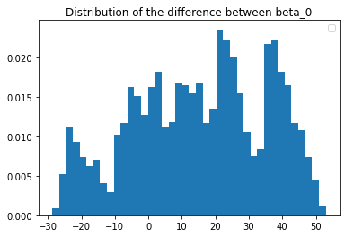

```python
plt.hist(burned_trace['beta_0']-second_burned_trace['beta_0'], bins=40, density=True)
plt.title('Distribution of the difference between beta_0')
plt.legend()
plt.show()
```

While the MAP solutions give the same estimation for β_0, we see that the two posteriors are rather different. Let us also compare the posterior distributions of β_temp between these two models.

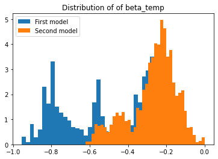

```python
plt.hist(burned_trace['beta_temp'], label='First model', bins=40, density=True)
plt.hist(second_burned_trace['beta_temp'], bins=40, label='Second model', density=True)
plt.title('Distribution of of beta_temp')
plt.legend()
plt.show()
```

```python
second_y_score = np.mean(second_burned_trace['p'], axis=0)
second_model_prediction=[1 if x >0.5 else 0 for x in second_y_score]
second_model_confussion_matrix =confusion_matrix(df['Failure'], second_model_prediction)
second_model_confussion_matrix
```

```
array([[15,  0],
       [ 3,  4]], dtype=int64)
```

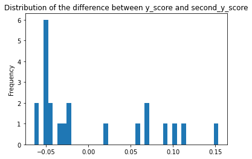

```python
plt.hist(y_score-second_y_score, bins=40)
plt.title('Distribution of the difference between y_score and second_y_score')
plt.ylabel('Frequency')
plt.show()
```

### Model-3: Built-in GLM of PyMC3

```
Auto-assigning NUTS sampler...
Initializing NUTS using adapt_diag...
Multiprocess sampling (2 chains in 2 jobs)
NUTS: [Temp, Intercept]
```

100.00% [70000/70000 44:42<00:00 Sampling 2 chains, 8 divergences]

```
Sampling 2 chains for 10_000 tune and 25_000 draw iterations (20_000 + 50_000 draws total) took 2691 seconds.
The acceptance probability does not match the target. It is 0.8955108504312126, but should be close to 0.8. Try to increase the number of tuning steps.
There were 8 divergences after tuning. Increase `target_accept` or reparameterize.
The acceptance probability does not match the target. It is 0.6765528743917142, but should be close to 0.8. Try to increase the number of tuning steps.
The number of effective samples is smaller than 10% for some parameters.
```

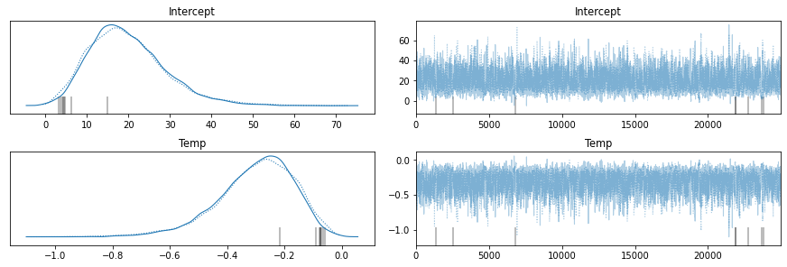

```python
with pm.Model() as third_model:
    pm.glm.GLM.from_formula('Failure ~ Temp',
                            df,
                            family=pm.glm.families.Binomial())
    third_trace = pm.sample(25000, tune=10000, init='adapt_diag')
pm.traceplot(third_trace)
plt.show()
```

Unlike the previous models, the posterior distributions of our parameters are unimodal in this case.

Let us get a summary of these posterior distributions.

```python
pm.summary(third_trace)
```

|  | mean | sd | hdi_3% | hdi_97% | mcse_mean | mcse_sd | ess_mean | ess_sd | ess_bulk | ess_tail | r_hat |
| --- | --- | --- | --- | --- | --- | --- | --- | --- | --- | --- | --- |
| Intercept | 19.773 | 9.260 | 3.906 | 37.429 | 0.176 | 0.125 | 2759.0 | 2759.0 | 2424.0 | 1819.0 | 1.0 |
| Temp | -0.300 | 0.135 | -0.547 | -0.058 | 0.003 | 0.002 | 2757.0 | 2757.0 | 2420.0 | 1842.0 | 1.0 |

```python
with third_model:
    map_solution=pm.find_MAP()
d=dict()
for item in map_solution.keys():
    d[item]=[float(map_solution[item])]

third_map_coeffs=pd.DataFrame.from_dict(d)
third_map_coeffs
```

100.00% [2/2 00:00<00:00 logp = -23.076, ||grad|| = 320.52]

|  | Intercept | Temp |
| --- | --- | --- |
| 0 | -0.01248 | -0.999922 |

We see that there is a significant difference between the MAP solutions between the second and the third model. What about prediction?

```python
with third_model:
    ppc = pm.sample_posterior_predictive(third_trace, samples=15000)#compute y_score
with third_model:
    third_y_score = np.mean(ppc['y'], axis=0)
#convert y_score into binary decisions
third_model_prediction=[1 if x >0.5 else 0 for x in third_y_score]#compute confussion matrix
third_model_confussion_matrix =confusion_matrix(df['Failure'], third_model_prediction)
third_model_confussion_matrix
```

100.00% [15000/15000 00:12<00:00]

```
array([[15,  0],
       [ 3,  4]], dtype=int64)
```

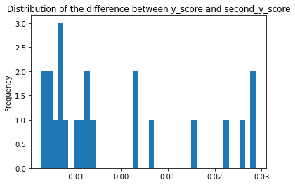

```python
plt.hist(third_y_score-second_y_score, bins=40)
plt.title('Distribution of the difference between y_score and second_y_score')
plt.ylabel('Frequency')
plt.show()
```